# Lab5- And, or, Pivot, pairplot and heatmap

Vismay Gehlot

### This Lab is open from 10/4 at 6 am to 10/6 at 3:30 pm

We will use the same baseball data set as in HW5. Here are the details for your reference. This dataset contains data concerning a baseball team's performance in a given year. It has the following variables:

Team: A code for the name of the team

League: The Major League Baseball league the team belongs to, either AL (American League) or NL (National League)

Year: The year of the corresponding record

RS: The number of runs scored by the team in that year

RA: The number of runs allowed by the team in that year

W: The number of regular season wins by the team in that year

OBP: The on-base percentage of the team in that year

SLG: The slugging percentage of the team in that year

BA: The batting average of the team in that year

Playoffs: Whether the team made the playoffs in that year (1 for yes, 0 for no)

RankSeason: Among the playoff teams in that year, the ranking of their regular season records (1 is best)

RankPlayoffs: Among the playoff teams in that year, how well they fared in the playoffs. The team winning the World Series gets a RankPlayoffs of 1.

G: The number of games a team played in that year

OOBP: The team's opponents' on-base percentage in that year

OSLG: The team's opponents' slugging percentage in that year

### Boolean Operators in python

Boolean is a type of value that can be either True or False. In Python, the Boolean type is bool, which is a subtype of int. Python has mainly 2 Boolean operators that are typed out as plain English words:

1. or
2. and

These operators connect Boolean expressions (and objects) to create compound Boolean expressions.

The Python Boolean operators always take two Boolean expressions or two objects or a combination of them, so they’re considered binary operators.

In this lab, we will be using these in the context of pandas dataframe.

### OR operator

When I write a or b, the statement "a or b" is TRUE in all of the following situations except the last:

- if a is true regradless of b being true or false.
- if b is true regardless of a being true or false.
- if both a and b are true
- "a or b" is false only when both a and b are false.

Let's apply "or" in our baseball data frame. The notation for the "or" operator is | (called pipe or vertical bar) sign. The set notation equivalent for "or" is the union of two sets...... i.e {1,3} | {2,3} = {1,2,3}.

### Total points for this Lab: 50

Each problem is worth 10 points

```python
import pandas as pd
import numpy as np
import matplotlib as mpt
import matplotlib.pyplot as plt
import seaborn as sns
baseball = pd.read_csv('baseball.csv')
# insert code here to create baseball data frame called "baseball" by
# reading the baseball.csv file
```

### Problem 1

Make a subset of the baseball data frame using the following code (first you have to create a data frame called "baseball" by reading the baseball.csv file).

Write a paragraph detailing how this new data set was selected in the context of the baseball data frame.

IN what ways would this new data frame you just created be more helpful as opposed to considering the original bigger data frame, which you called baseball?

This dataframe was created by choosing either teams who had a batting average above the average of all the teams in the database, or teams who had over 90 wins in the season. This dataframe is better than the generic baseball dataframe because it allows us to see the superior teams in the league, whether that be based of batting averages or overall wins

```python
baseball1 = baseball[(baseball.W>90) | (baseball.BA>np.mean(baseball.BA))]

baseball1
```

|  | Team | League | Year | RS | RA | W | OBP | SLG | BA | Playoffs | RankSeason | RankPlayoffs | G | OOBP | OSLG |
| --- | --- | --- | --- | --- | --- | --- | --- | --- | --- | --- | --- | --- | --- | --- | --- |
| 1 | ATL | NL | 2012 | 700 | 600 | 94 | 0.320 | 0.389 | 0.247 | 1 | 4.0 | 5.0 | 162 | 0.306 | 0.378 |
| 2 | BAL | AL | 2012 | 712 | 705 | 93 | 0.311 | 0.417 | 0.247 | 1 | 5.0 | 4.0 | 162 | 0.315 | 0.403 |
| 3 | BOS | AL | 2012 | 734 | 806 | 69 | 0.315 | 0.415 | 0.260 | 0 | NaN | NaN | 162 | 0.331 | 0.428 |
| 6 | CIN | NL | 2012 | 669 | 588 | 97 | 0.315 | 0.411 | 0.251 | 1 | 2.0 | 4.0 | 162 | 0.305 | 0.390 |
| 8 | COL | NL | 2012 | 758 | 890 | 64 | 0.330 | 0.436 | 0.274 | 0 | NaN | NaN | 162 | 0.357 | 0.470 |
| 9 | DET | AL | 2012 | 726 | 670 | 88 | 0.335 | 0.422 | 0.268 | 1 | 6.0 | 2.0 | 162 | 0.314 | 0.402 |
| 11 | KCR | AL | 2012 | 676 | 746 | 72 | 0.317 | 0.400 | 0.265 | 0 | NaN | NaN | 162 | 0.339 | 0.423 |
| 12 | LAA | AL | 2012 | 767 | 699 | 89 | 0.332 | 0.433 | 0.274 | 0 | NaN | NaN | 162 | 0.310 | 0.403 |
| 16 | MIN | AL | 2012 | 701 | 832 | 66 | 0.325 | 0.390 | 0.260 | 0 | NaN | NaN | 162 | 0.333 | 0.442 |
| 18 | NYY | AL | 2012 | 804 | 668 | 95 | 0.337 | 0.453 | 0.265 | 1 | 3.0 | 3.0 | 162 | 0.311 | 0.419 |
| 19 | OAK | AL | 2012 | 713 | 614 | 94 | 0.310 | 0.404 | 0.238 | 1 | 4.0 | 4.0 | 162 | 0.306 | 0.378 |
| 24 | SFG | NL | 2012 | 718 | 649 | 94 | 0.327 | 0.397 | 0.269 | 1 | 4.0 | 1.0 | 162 | 0.313 | 0.393 |
| 25 | STL | NL | 2012 | 765 | 648 | 88 | 0.338 | 0.421 | 0.271 | 1 | 6.0 | 3.0 | 162 | 0.313 | 0.387 |
| 27 | TEX | AL | 2012 | 808 | 707 | 93 | 0.334 | 0.446 | 0.273 | 1 | 5.0 | 5.0 | 162 | 0.309 | 0.408 |
| 29 | WSN | NL | 2012 | 731 | 594 | 98 | 0.322 | 0.428 | 0.261 | 1 | 1.0 | 4.0 | 162 | 0.303 | 0.373 |
| 30 | ARI | NL | 2011 | 731 | 662 | 94 | 0.322 | 0.413 | 0.250 | 1 | 5.0 | 4.0 | 162 | 0.316 | 0.409 |
| 33 | BOS | AL | 2011 | 875 | 737 | 90 | 0.349 | 0.461 | 0.280 | 0 | NaN | NaN | 162 | 0.322 | 0.392 |
| 39 | DET | AL | 2011 | 787 | 711 | 95 | 0.340 | 0.434 | 0.277 | 1 | 4.0 | 3.0 | 162 | 0.321 | 0.396 |
| 42 | KCR | AL | 2011 | 730 | 762 | 71 | 0.329 | 0.415 | 0.275 | 0 | NaN | NaN | 162 | 0.337 | 0.425 |
| 45 | MIL | NL | 2011 | 721 | 638 | 96 | 0.325 | 0.425 | 0.261 | 1 | 3.0 | 3.0 | 162 | 0.304 | 0.385 |
| 47 | NYM | NL | 2011 | 718 | 742 | 77 | 0.335 | 0.391 | 0.264 | 0 | NaN | NaN | 162 | 0.332 | 0.411 |
| 48 | NYY | AL | 2011 | 867 | 657 | 97 | 0.343 | 0.444 | 0.263 | 1 | 2.0 | 4.0 | 162 | 0.322 | 0.399 |
| 50 | PHI | NL | 2011 | 713 | 529 | 102 | 0.323 | 0.395 | 0.253 | 1 | 1.0 | 4.0 | 162 | 0.296 | 0.361 |
| 55 | STL | NL | 2011 | 762 | 692 | 90 | 0.341 | 0.425 | 0.273 | 1 | 7.0 | 1.0 | 162 | 0.319 | 0.398 |
| 56 | TBR | AL | 2011 | 707 | 614 | 91 | 0.322 | 0.402 | 0.244 | 1 | 6.0 | 4.0 | 162 | 0.303 | 0.383 |
| 57 | TEX | AL | 2011 | 855 | 677 | 96 | 0.340 | 0.460 | 0.283 | 1 | 3.0 | 2.0 | 162 | 0.307 | 0.392 |
| 61 | ATL | NL | 2010 | 738 | 629 | 91 | 0.339 | 0.401 | 0.258 | 1 | 6.0 | 4.0 | 162 | 0.314 | 0.376 |
| 63 | BOS | AL | 2010 | 818 | 744 | 89 | 0.339 | 0.451 | 0.268 | 0 | NaN | NaN | 162 | 0.327 | 0.399 |
| 65 | CHW | AL | 2010 | 752 | 704 | 88 | 0.332 | 0.420 | 0.268 | 0 | NaN | NaN | 162 | 0.325 | 0.395 |
| 66 | CIN | NL | 2010 | 790 | 685 | 91 | 0.338 | 0.436 | 0.272 | 1 | 6.0 | 4.0 | 162 | 0.323 | 0.396 |
| ... | ... | ... | ... | ... | ... | ... | ... | ... | ... | ... | ... | ... | ... | ... | ... |
| 1149 | SFG | NL | 1966 | 675 | 626 | 93 | 0.303 | 0.392 | 0.248 | 0 | NaN | NaN | 161 | NaN | NaN |
| 1152 | BAL | AL | 1965 | 641 | 578 | 94 | 0.307 | 0.363 | 0.238 | 0 | NaN | NaN | 162 | NaN | NaN |
| 1156 | CHW | AL | 1965 | 647 | 555 | 95 | 0.315 | 0.364 | 0.246 | 0 | NaN | NaN | 162 | NaN | NaN |
| 1157 | CIN | NL | 1965 | 825 | 704 | 89 | 0.339 | 0.439 | 0.273 | 0 | NaN | NaN | 162 | NaN | NaN |
| 1162 | LAD | NL | 1965 | 608 | 521 | 97 | 0.312 | 0.335 | 0.245 | 1 | 2.0 | 1.0 | 162 | NaN | NaN |
| 1163 | MIN | AL | 1965 | 774 | 600 | 102 | 0.324 | 0.399 | 0.254 | 1 | 1.0 | 2.0 | 162 | NaN | NaN |
| 1168 | PIT | NL | 1965 | 675 | 580 | 90 | 0.317 | 0.382 | 0.265 | 0 | NaN | NaN | 163 | NaN | NaN |
| 1169 | SFG | NL | 1965 | 682 | 593 | 95 | 0.313 | 0.385 | 0.252 | 0 | NaN | NaN | 163 | NaN | NaN |
| 1172 | BAL | AL | 1964 | 679 | 567 | 97 | 0.316 | 0.387 | 0.248 | 0 | NaN | NaN | 163 | NaN | NaN |
| 1175 | CHW | AL | 1964 | 642 | 501 | 98 | 0.320 | 0.353 | 0.247 | 0 | NaN | NaN | 162 | NaN | NaN |
| 1176 | CIN | NL | 1964 | 660 | 566 | 92 | 0.308 | 0.372 | 0.249 | 0 | NaN | NaN | 163 | NaN | NaN |
| 1184 | MLN | NL | 1964 | 803 | 744 | 88 | 0.333 | 0.418 | 0.272 | 0 | NaN | NaN | 162 | NaN | NaN |
| 1186 | NYY | AL | 1964 | 730 | 577 | 99 | 0.317 | 0.387 | 0.253 | 1 | 1.0 | 2.0 | 164 | NaN | NaN |
| 1187 | PHI | NL | 1964 | 693 | 632 | 92 | 0.315 | 0.391 | 0.258 | 0 | NaN | NaN | 162 | NaN | NaN |
| 1188 | PIT | NL | 1964 | 663 | 636 | 80 | 0.315 | 0.389 | 0.264 | 0 | NaN | NaN | 162 | NaN | NaN |
| 1190 | STL | NL | 1964 | 715 | 652 | 93 | 0.324 | 0.392 | 0.272 | 1 | 2.0 | 1.0 | 162 | NaN | NaN |
| 1195 | CHW | AL | 1963 | 683 | 544 | 94 | 0.323 | 0.365 | 0.250 | 0 | NaN | NaN | 162 | NaN | NaN |
| 1202 | LAD | NL | 1963 | 640 | 550 | 99 | 0.309 | 0.357 | 0.251 | 1 | 2.0 | 1.0 | 163 | NaN | NaN |
| 1203 | MIN | AL | 1963 | 767 | 602 | 91 | 0.325 | 0.430 | 0.255 | 0 | NaN | NaN | 161 | NaN | NaN |
| 1206 | NYY | AL | 1963 | 714 | 547 | 104 | 0.309 | 0.403 | 0.252 | 1 | 1.0 | 2.0 | 161 | NaN | NaN |
| 1210 | STL | NL | 1963 | 747 | 628 | 93 | 0.326 | 0.403 | 0.271 | 0 | NaN | NaN | 162 | NaN | NaN |
| 1216 | CIN | NL | 1962 | 802 | 685 | 98 | 0.332 | 0.417 | 0.270 | 0 | NaN | NaN | 162 | NaN | NaN |
| 1220 | KCA | AL | 1962 | 745 | 837 | 72 | 0.332 | 0.386 | 0.263 | 0 | NaN | NaN | 162 | NaN | NaN |
| 1222 | LAD | NL | 1962 | 842 | 697 | 102 | 0.337 | 0.400 | 0.268 | 0 | NaN | NaN | 165 | NaN | NaN |
| 1223 | MIN | AL | 1962 | 798 | 713 | 91 | 0.338 | 0.412 | 0.260 | 0 | NaN | NaN | 163 | NaN | NaN |
| 1226 | NYY | AL | 1962 | 817 | 680 | 96 | 0.337 | 0.426 | 0.267 | 1 | 2.0 | 1.0 | 162 | NaN | NaN |
| 1227 | PHI | NL | 1962 | 705 | 759 | 81 | 0.330 | 0.390 | 0.260 | 0 | NaN | NaN | 161 | NaN | NaN |
| 1228 | PIT | NL | 1962 | 706 | 626 | 93 | 0.321 | 0.394 | 0.268 | 0 | NaN | NaN | 161 | NaN | NaN |
| 1229 | SFG | NL | 1962 | 878 | 690 | 103 | 0.341 | 0.441 | 0.278 | 1 | 1.0 | 2.0 | 165 | NaN | NaN |
| 1230 | STL | NL | 1962 | 774 | 664 | 84 | 0.335 | 0.394 | 0.271 | 0 | NaN | NaN | 163 | NaN | NaN |

690 rows × 15 columns

```python
baseball1[['Team','Playoffs']]
```

|  | Team | Playoffs |
| --- | --- | --- |
| 1 | ATL | 1 |
| 2 | BAL | 1 |
| 3 | BOS | 0 |
| 6 | CIN | 1 |
| 8 | COL | 0 |
| 9 | DET | 1 |
| 11 | KCR | 0 |
| 12 | LAA | 0 |
| 16 | MIN | 0 |
| 18 | NYY | 1 |
| 19 | OAK | 1 |
| 24 | SFG | 1 |
| 25 | STL | 1 |
| 27 | TEX | 1 |
| 29 | WSN | 1 |
| 30 | ARI | 1 |
| 33 | BOS | 0 |
| 39 | DET | 1 |
| 42 | KCR | 0 |
| 45 | MIL | 1 |
| 47 | NYM | 0 |
| 48 | NYY | 1 |
| 50 | PHI | 1 |
| 55 | STL | 1 |
| 56 | TBR | 1 |
| 57 | TEX | 1 |
| 61 | ATL | 1 |
| 63 | BOS | 0 |
| 65 | CHW | 0 |
| 66 | CIN | 1 |
| ... | ... | ... |
| 1149 | SFG | 0 |
| 1152 | BAL | 0 |
| 1156 | CHW | 0 |
| 1157 | CIN | 0 |
| 1162 | LAD | 1 |
| 1163 | MIN | 1 |
| 1168 | PIT | 0 |
| 1169 | SFG | 0 |
| 1172 | BAL | 0 |
| 1175 | CHW | 0 |
| 1176 | CIN | 0 |
| 1184 | MLN | 0 |
| 1186 | NYY | 1 |
| 1187 | PHI | 0 |
| 1188 | PIT | 0 |
| 1190 | STL | 1 |
| 1195 | CHW | 0 |
| 1202 | LAD | 1 |
| 1203 | MIN | 0 |
| 1206 | NYY | 1 |
| 1210 | STL | 0 |
| 1216 | CIN | 0 |
| 1220 | KCA | 0 |
| 1222 | LAD | 0 |
| 1223 | MIN | 0 |
| 1226 | NYY | 1 |
| 1227 | PHI | 0 |
| 1228 | PIT | 0 |
| 1229 | SFG | 1 |
| 1230 | STL | 0 |

690 rows × 2 columns

### AND operator

When I write a and b, the statement "a and b" is FALSE in all of the following situations except the last:

- a and b is false if a is true and b is false
- a and b is false if a is false and b is true
- a and b is false if a is false and b is false
- a and b is true only when both a and b are both true.

Let's apply "and" in our baseball data frame. The notation for the "and" operator is & (called ampersand) sign. Set equivalent notation for "AND" is intersection....... i.e {1,3} & {2,3} = {3}.

### Problem 2

Use the same code as in Problem 1 with | replaced by & and find a new data frame.

Compare the shape of this new data frame with the data frame from Problem 1 and explain why we got a smaller data set.

Make a table of playoff values/teams from the dataframes from both the problems and comment on the tables. So you'll be creating 3 data frames in this problem.

This is a significantly smaller dataset because it chooses teams who have both an above average batting average and more than 90 wins, instead of one or the other.

```python
baseball2 = baseball[(baseball.W>90) & (baseball.BA>np.mean(baseball.BA))]

baseball2
```

|  | Team | League | Year | RS | RA | W | OBP | SLG | BA | Playoffs | RankSeason | RankPlayoffs | G | OOBP | OSLG |
| --- | --- | --- | --- | --- | --- | --- | --- | --- | --- | --- | --- | --- | --- | --- | --- |
| 18 | NYY | AL | 2012 | 804 | 668 | 95 | 0.337 | 0.453 | 0.265 | 1 | 3.0 | 3.0 | 162 | 0.311 | 0.419 |
| 24 | SFG | NL | 2012 | 718 | 649 | 94 | 0.327 | 0.397 | 0.269 | 1 | 4.0 | 1.0 | 162 | 0.313 | 0.393 |
| 27 | TEX | AL | 2012 | 808 | 707 | 93 | 0.334 | 0.446 | 0.273 | 1 | 5.0 | 5.0 | 162 | 0.309 | 0.408 |
| 29 | WSN | NL | 2012 | 731 | 594 | 98 | 0.322 | 0.428 | 0.261 | 1 | 1.0 | 4.0 | 162 | 0.303 | 0.373 |
| 39 | DET | AL | 2011 | 787 | 711 | 95 | 0.340 | 0.434 | 0.277 | 1 | 4.0 | 3.0 | 162 | 0.321 | 0.396 |
| 45 | MIL | NL | 2011 | 721 | 638 | 96 | 0.325 | 0.425 | 0.261 | 1 | 3.0 | 3.0 | 162 | 0.304 | 0.385 |
| 48 | NYY | AL | 2011 | 867 | 657 | 97 | 0.343 | 0.444 | 0.263 | 1 | 2.0 | 4.0 | 162 | 0.322 | 0.399 |
| 57 | TEX | AL | 2011 | 855 | 677 | 96 | 0.340 | 0.460 | 0.283 | 1 | 3.0 | 2.0 | 162 | 0.307 | 0.392 |
| 66 | CIN | NL | 2010 | 790 | 685 | 91 | 0.338 | 0.436 | 0.272 | 1 | 6.0 | 4.0 | 162 | 0.323 | 0.396 |
| 76 | MIN | AL | 2010 | 781 | 671 | 94 | 0.341 | 0.422 | 0.273 | 1 | 4.0 | 4.0 | 162 | 0.317 | 0.417 |
| 78 | NYY | AL | 2010 | 859 | 693 | 95 | 0.350 | 0.436 | 0.267 | 1 | 3.0 | 3.0 | 162 | 0.322 | 0.399 |
| 80 | PHI | NL | 2010 | 772 | 640 | 97 | 0.332 | 0.413 | 0.260 | 1 | 1.0 | 3.0 | 162 | 0.311 | 0.405 |
| 93 | BOS | AL | 2009 | 872 | 736 | 95 | 0.352 | 0.454 | 0.270 | 1 | 3.0 | 4.0 | 162 | 0.335 | 0.422 |
| 98 | COL | NL | 2009 | 804 | 715 | 92 | 0.343 | 0.441 | 0.261 | 1 | 5.0 | 4.0 | 162 | 0.328 | 0.405 |
| 103 | LAA | AL | 2009 | 883 | 761 | 97 | 0.350 | 0.441 | 0.285 | 1 | 2.0 | 3.0 | 162 | 0.338 | 0.432 |
| 104 | LAD | NL | 2009 | 780 | 611 | 95 | 0.346 | 0.412 | 0.270 | 1 | 3.0 | 3.0 | 162 | 0.312 | 0.361 |
| 108 | NYY | AL | 2009 | 915 | 753 | 103 | 0.362 | 0.478 | 0.283 | 1 | 1.0 | 1.0 | 162 | 0.327 | 0.408 |
| 115 | STL | NL | 2009 | 730 | 640 | 91 | 0.332 | 0.415 | 0.263 | 1 | 6.0 | 4.0 | 162 | 0.319 | 0.386 |
| 123 | BOS | AL | 2008 | 845 | 694 | 95 | 0.358 | 0.447 | 0.280 | 1 | 3.0 | 3.0 | 162 | 0.323 | 0.390 |
| 124 | CHC | NL | 2008 | 855 | 671 | 97 | 0.354 | 0.443 | 0.278 | 1 | 2.0 | 4.0 | 161 | 0.316 | 0.395 |
| 133 | LAA | AL | 2008 | 765 | 697 | 100 | 0.330 | 0.413 | 0.268 | 1 | 1.0 | 4.0 | 162 | 0.323 | 0.406 |
| 146 | TBR | AL | 2008 | 774 | 671 | 97 | 0.340 | 0.422 | 0.260 | 1 | 2.0 | 2.0 | 162 | 0.314 | 0.400 |
| 153 | BOS | AL | 2007 | 867 | 657 | 96 | 0.362 | 0.444 | 0.279 | 1 | 1.0 | 1.0 | 162 | 0.314 | 0.392 |
| 157 | CLE | AL | 2007 | 811 | 704 | 96 | 0.343 | 0.428 | 0.268 | 1 | 1.0 | 3.0 | 162 | 0.322 | 0.407 |
| 163 | LAA | AL | 2007 | 822 | 731 | 94 | 0.345 | 0.417 | 0.284 | 1 | 2.0 | 4.0 | 162 | 0.328 | 0.412 |
| 168 | NYY | AL | 2007 | 968 | 777 | 94 | 0.366 | 0.463 | 0.290 | 1 | 2.0 | 4.0 | 162 | 0.340 | 0.417 |
| 189 | DET | AL | 2006 | 822 | 675 | 95 | 0.329 | 0.449 | 0.274 | 1 | 3.0 | 2.0 | 162 | 0.321 | 0.405 |
| 196 | MIN | AL | 2006 | 801 | 683 | 96 | 0.347 | 0.425 | 0.287 | 1 | 2.0 | 4.0 | 162 | 0.312 | 0.423 |
| 197 | NYM | NL | 2006 | 834 | 731 | 97 | 0.334 | 0.445 | 0.264 | 1 | 1.0 | 3.0 | 162 | 0.323 | 0.407 |
| 198 | NYY | AL | 2006 | 930 | 767 | 97 | 0.363 | 0.461 | 0.285 | 1 | 1.0 | 4.0 | 162 | 0.326 | 0.413 |
| ... | ... | ... | ... | ... | ... | ... | ... | ... | ... | ... | ... | ... | ... | ... | ... |
| 922 | TEX | AL | 1977 | 767 | 657 | 94 | 0.342 | 0.405 | 0.270 | 0 | NaN | NaN | 162 | NaN | NaN |
| 930 | CIN | NL | 1976 | 857 | 633 | 102 | 0.357 | 0.424 | 0.280 | 1 | 1.0 | 1.0 | 162 | NaN | NaN |
| 940 | NYY | AL | 1976 | 730 | 575 | 97 | 0.328 | 0.389 | 0.269 | 1 | 3.0 | 2.0 | 159 | NaN | NaN |
| 942 | PHI | NL | 1976 | 770 | 557 | 101 | 0.338 | 0.395 | 0.272 | 1 | 2.0 | 3.0 | 162 | NaN | NaN |
| 943 | PIT | NL | 1976 | 708 | 630 | 92 | 0.321 | 0.391 | 0.267 | 0 | NaN | NaN | 162 | NaN | NaN |
| 950 | BOS | AL | 1975 | 796 | 709 | 95 | 0.344 | 0.417 | 0.275 | 1 | 3.0 | 2.0 | 160 | NaN | NaN |
| 954 | CIN | NL | 1975 | 840 | 586 | 108 | 0.353 | 0.401 | 0.271 | 1 | 1.0 | 1.0 | 162 | NaN | NaN |
| 958 | KCR | AL | 1975 | 710 | 649 | 91 | 0.333 | 0.394 | 0.261 | 0 | NaN | NaN | 162 | NaN | NaN |
| 967 | PIT | NL | 1975 | 712 | 565 | 92 | 0.323 | 0.402 | 0.263 | 1 | 4.0 | 3.0 | 161 | NaN | NaN |
| 978 | CIN | NL | 1974 | 776 | 631 | 98 | 0.343 | 0.394 | 0.260 | 0 | NaN | NaN | 163 | NaN | NaN |
| 983 | LAD | NL | 1974 | 798 | 561 | 102 | 0.342 | 0.401 | 0.272 | 1 | 1.0 | 2.0 | 162 | NaN | NaN |
| 997 | BAL | AL | 1973 | 754 | 561 | 97 | 0.345 | 0.389 | 0.266 | 1 | 2.0 | 3.0 | 162 | NaN | NaN |
| 1007 | LAD | NL | 1973 | 675 | 565 | 95 | 0.323 | 0.371 | 0.263 | 0 | NaN | NaN | 162 | NaN | NaN |
| 1013 | OAK | AL | 1973 | 758 | 615 | 94 | 0.333 | 0.389 | 0.260 | 1 | 3.0 | 1.0 | 162 | NaN | NaN |
| 1021 | BAL | AL | 1971 | 742 | 530 | 101 | 0.347 | 0.398 | 0.261 | 1 | 1.0 | 2.0 | 158 | NaN | NaN |
| 1039 | PIT | NL | 1971 | 788 | 599 | 97 | 0.330 | 0.416 | 0.274 | 1 | 2.0 | 1.0 | 162 | NaN | NaN |
| 1050 | CIN | NL | 1970 | 775 | 681 | 102 | 0.336 | 0.436 | 0.270 | 1 | 2.0 | 2.0 | 162 | NaN | NaN |
| 1057 | MIN | AL | 1970 | 744 | 605 | 98 | 0.327 | 0.403 | 0.262 | 1 | 3.0 | 3.0 | 162 | NaN | NaN |
| 1069 | BAL | AL | 1969 | 779 | 517 | 109 | 0.343 | 0.414 | 0.265 | 1 | 1.0 | 2.0 | 162 | NaN | NaN |
| 1080 | MIN | AL | 1969 | 790 | 618 | 97 | 0.340 | 0.408 | 0.268 | 1 | 3.0 | 3.0 | 162 | NaN | NaN |
| 1130 | STL | NL | 1967 | 695 | 557 | 101 | 0.320 | 0.379 | 0.263 | 1 | 1.0 | 1.0 | 161 | NaN | NaN |
| 1148 | PIT | NL | 1966 | 759 | 641 | 92 | 0.329 | 0.428 | 0.279 | 0 | NaN | NaN | 162 | NaN | NaN |
| 1190 | STL | NL | 1964 | 715 | 652 | 93 | 0.324 | 0.392 | 0.272 | 1 | 2.0 | 1.0 | 162 | NaN | NaN |
| 1210 | STL | NL | 1963 | 747 | 628 | 93 | 0.326 | 0.403 | 0.271 | 0 | NaN | NaN | 162 | NaN | NaN |
| 1216 | CIN | NL | 1962 | 802 | 685 | 98 | 0.332 | 0.417 | 0.270 | 0 | NaN | NaN | 162 | NaN | NaN |
| 1222 | LAD | NL | 1962 | 842 | 697 | 102 | 0.337 | 0.400 | 0.268 | 0 | NaN | NaN | 165 | NaN | NaN |
| 1223 | MIN | AL | 1962 | 798 | 713 | 91 | 0.338 | 0.412 | 0.260 | 0 | NaN | NaN | 163 | NaN | NaN |
| 1226 | NYY | AL | 1962 | 817 | 680 | 96 | 0.337 | 0.426 | 0.267 | 1 | 2.0 | 1.0 | 162 | NaN | NaN |
| 1228 | PIT | NL | 1962 | 706 | 626 | 93 | 0.321 | 0.394 | 0.268 | 0 | NaN | NaN | 161 | NaN | NaN |
| 1229 | SFG | NL | 1962 | 878 | 690 | 103 | 0.341 | 0.441 | 0.278 | 1 | 1.0 | 2.0 | 165 | NaN | NaN |

188 rows × 15 columns

```python
baseball2[['Team','Playoffs']]
```

|  | Team | Playoffs |
| --- | --- | --- |
| 18 | NYY | 1 |
| 24 | SFG | 1 |
| 27 | TEX | 1 |
| 29 | WSN | 1 |
| 39 | DET | 1 |
| 45 | MIL | 1 |
| 48 | NYY | 1 |
| 57 | TEX | 1 |
| 66 | CIN | 1 |
| 76 | MIN | 1 |
| 78 | NYY | 1 |
| 80 | PHI | 1 |
| 93 | BOS | 1 |
| 98 | COL | 1 |
| 103 | LAA | 1 |
| 104 | LAD | 1 |
| 108 | NYY | 1 |
| 115 | STL | 1 |
| 123 | BOS | 1 |
| 124 | CHC | 1 |
| 133 | LAA | 1 |
| 146 | TBR | 1 |
| 153 | BOS | 1 |
| 157 | CLE | 1 |
| 163 | LAA | 1 |
| 168 | NYY | 1 |
| 189 | DET | 1 |
| 196 | MIN | 1 |
| 197 | NYM | 1 |
| 198 | NYY | 1 |
| ... | ... | ... |
| 922 | TEX | 0 |
| 930 | CIN | 1 |
| 940 | NYY | 1 |
| 942 | PHI | 1 |
| 943 | PIT | 0 |
| 950 | BOS | 1 |
| 954 | CIN | 1 |
| 958 | KCR | 0 |
| 967 | PIT | 1 |
| 978 | CIN | 0 |
| 983 | LAD | 1 |
| 997 | BAL | 1 |
| 1007 | LAD | 0 |
| 1013 | OAK | 1 |
| 1021 | BAL | 1 |
| 1039 | PIT | 1 |
| 1050 | CIN | 1 |
| 1057 | MIN | 1 |
| 1069 | BAL | 1 |
| 1080 | MIN | 1 |
| 1130 | STL | 1 |
| 1148 | PIT | 0 |
| 1190 | STL | 1 |
| 1210 | STL | 0 |
| 1216 | CIN | 0 |
| 1222 | LAD | 0 |
| 1223 | MIN | 0 |
| 1226 | NYY | 1 |
| 1228 | PIT | 0 |
| 1229 | SFG | 1 |

188 rows × 2 columns

### Pivot Table in Pandas.

A pivot table is a data processing tool used to query, organize, and summarize data or information between spreadsheets, tables, or databases.

The generic pivot table term is used by many companies and software vendors. PivotTable, Microsoft branded and trademarked version, is used in most Excel products. We will use PivotTable in pandas. A pivot table is useful when analyzing a large amount of data, as it allows users to apply specific criteria to summarize, organize and reorganize data tables, and create reports.

For example, when a store manager reviews the sales of a specific item over a six-month period, he must sift through many pages of relevant and irrelevant data. A pivot table, however, simplifies this process by automatically counting, summarizing, and sorting the data. Summarized data may then be used to create a report tailored to the item's activity within the specified six-month parameter, reducing data output and table rows and columns. This process may be used to accommodate various data requirements.

### Problem 3

Use the following code (where "yourdf" is the name of the original data frame you created from the baseball data file). This code will use our data to pivot the column variable W, index the summary by League name, and order the columns by Year.

Explain why we'd want to create a table like this (meaning: In what way is this information on the pivot table useful?)

A pivot table is useful because it allows us to take 2 specific categories and compare them. Using the pivot table below we can directly compare wins between the american and the national league on a yearly basis

```python
baseball.pivot_table(values ='W',index=["League"], columns= ['Year'])
#Here I did not specify the function to be used so the default is mean.
```

| Year League | 1962 | 1963 | 1964 | 1965 | 1966 | 1967 | 1968 | 1969 | 1970 | 1971 | ... | 2003 | 2004 | 2005 | 2006 | 2007 | 2008 | 2009 | 2010 | 2011 | 2012 |
| --- | --- | --- | --- | --- | --- | --- | --- | --- | --- | --- | --- | --- | --- | --- | --- | --- | --- | --- | --- | --- | --- |
| AL | 80.8 | 80.8 | 81.0 | 81.0 | 80.5 | 80.8 | 80.9 | 80.916667 | 81.000000 | 80.416667 | ... | 80.214286 | 81.000 | 81.714286 | 83.0000 | 81.785714 | 82.642857 | 81.928571 | 81.571429 | 81.357143 | 82.142857 |
| NL | 81.0 | 81.0 | 81.0 | 80.9 | 80.8 | 80.9 | 81.0 | 81.000000 | 80.916667 | 80.916667 | ... | 81.625000 | 80.875 | 80.375000 | 79.1875 | 80.375000 | 79.437500 | 80.187500 | 80.500000 | 80.625000 | 80.000000 |

2 rows × 47 columns

### Problem 4

In some situations, pivot table works just like the groupby function we did in our previous assignments. Use the code below (where, again, "yourdf" is the name of the original data frame you created from the baseball data file). Explain the pivoting done.

Save this new pivot table as a csv file in your working folder.

Read this new csv file back in pandas to see if it worked.

Confirm to yourselves that the outputs display the same information. Answer the question: Why do the outputs appear different (i.e when you create the pivot table versus when you read it back in pandas after saving)?

This dataset is used to group by leagues. Once that's done, it also counts other information like playoff rates, and rank seasons

```python
pd.pivot_table(baseball,index=["League","Team"],values =['Playoffs', 'RankSeason', 'RankPlayoffs',],aggfunc=np.mean)
```

| League | Team | Playoffs | RankPlayoffs | RankSeason |
| --- | --- | --- | --- | --- |
| AL | ANA | 0.250000 | 2.500000 | 4.500000 |
|  | BAL | 0.234043 | 2.272727 | 2.181818 |
|  | BOS | 0.276596 | 2.692308 | 3.384615 |
|  | CAL | 0.107143 | 3.000000 | 3.333333 |
|  | CHW | 0.106383 | 3.000000 | 3.000000 |
|  | CLE | 0.127660 | 3.333333 | 4.166667 |
|  | DET | 0.127660 | 2.000000 | 2.666667 |
|  | KCA | 0.000000 | NaN | NaN |
|  | KCR | 0.150000 | 2.500000 | 3.000000 |
|  | LAA | 0.363636 | 3.500000 | 2.000000 |
|  | MIL | 0.041667 | 2.000000 | 1.000000 |
|  | MIN | 0.234043 | 3.000000 | 4.090909 |
|  | NYY | 0.489362 | 2.347826 | 2.130435 |
|  | OAK | 0.341463 | 2.785714 | 2.285714 |
|  | SEA | 0.090909 | 3.333333 | 3.333333 |
|  | SEP | 0.000000 | NaN | NaN |
|  | TBD | 0.000000 | NaN | NaN |
|  | TBR | 0.600000 | 3.333333 | 3.333333 |
|  | TEX | 0.162162 | 3.500000 | 5.500000 |
|  | TOR | 0.151515 | 2.200000 | 3.000000 |
|  | WSA | 0.000000 | NaN | NaN |
| NL | ARI | 0.333333 | 3.200000 | 3.800000 |
|  | ATL | 0.395349 | 3.235294 | 2.882353 |
|  | CHC | 0.127660 | 3.500000 | 4.000000 |
|  | CIN | 0.170213 | 2.375000 | 2.375000 |
|  | COL | 0.111111 | 3.000000 | 4.000000 |
|  | FLA | 0.117647 | 1.000000 | 4.500000 |
|  | HOU | 0.170213 | 3.375000 | 4.250000 |
|  | LAD | 0.297872 | 2.500000 | 3.357143 |
|  | MIA | 0.000000 | NaN | NaN |
|  | MIL | 0.133333 | 3.500000 | 4.000000 |
|  | MLN | 0.000000 | NaN | NaN |
|  | MON | 0.000000 | NaN | NaN |
|  | NYM | 0.148936 | 2.142857 | 2.428571 |
|  | PHI | 0.234043 | 2.545455 | 2.909091 |
|  | PIT | 0.170213 | 2.500000 | 2.625000 |
|  | SDP | 0.125000 | 3.200000 | 4.400000 |
|  | SFG | 0.212766 | 2.600000 | 3.300000 |
|  | STL | 0.340426 | 2.250000 | 3.437500 |
|  | WSN | 0.125000 | 4.000000 | 1.000000 |

```python
pd.pivot_table(baseball,index=["League","Team"],values =['Playoffs', 'RankSeason', 'RankPlayoffs',],aggfunc=np.mean).to_csv('filename.csv')
```

```python
df = pd.read_csv('filename.csv')

df
```

|  | League | Team | Playoffs | RankPlayoffs | RankSeason |
| --- | --- | --- | --- | --- | --- |
| 0 | AL | ANA | 0.250000 | 2.500000 | 4.500000 |
| 1 | AL | BAL | 0.234043 | 2.272727 | 2.181818 |
| 2 | AL | BOS | 0.276596 | 2.692308 | 3.384615 |
| 3 | AL | CAL | 0.107143 | 3.000000 | 3.333333 |
| 4 | AL | CHW | 0.106383 | 3.000000 | 3.000000 |
| 5 | AL | CLE | 0.127660 | 3.333333 | 4.166667 |
| 6 | AL | DET | 0.127660 | 2.000000 | 2.666667 |
| 7 | AL | KCA | 0.000000 | NaN | NaN |
| 8 | AL | KCR | 0.150000 | 2.500000 | 3.000000 |
| 9 | AL | LAA | 0.363636 | 3.500000 | 2.000000 |
| 10 | AL | MIL | 0.041667 | 2.000000 | 1.000000 |
| 11 | AL | MIN | 0.234043 | 3.000000 | 4.090909 |
| 12 | AL | NYY | 0.489362 | 2.347826 | 2.130435 |
| 13 | AL | OAK | 0.341463 | 2.785714 | 2.285714 |
| 14 | AL | SEA | 0.090909 | 3.333333 | 3.333333 |
| 15 | AL | SEP | 0.000000 | NaN | NaN |
| 16 | AL | TBD | 0.000000 | NaN | NaN |
| 17 | AL | TBR | 0.600000 | 3.333333 | 3.333333 |
| 18 | AL | TEX | 0.162162 | 3.500000 | 5.500000 |
| 19 | AL | TOR | 0.151515 | 2.200000 | 3.000000 |
| 20 | AL | WSA | 0.000000 | NaN | NaN |
| 21 | NL | ARI | 0.333333 | 3.200000 | 3.800000 |
| 22 | NL | ATL | 0.395349 | 3.235294 | 2.882353 |
| 23 | NL | CHC | 0.127660 | 3.500000 | 4.000000 |
| 24 | NL | CIN | 0.170213 | 2.375000 | 2.375000 |
| 25 | NL | COL | 0.111111 | 3.000000 | 4.000000 |
| 26 | NL | FLA | 0.117647 | 1.000000 | 4.500000 |
| 27 | NL | HOU | 0.170213 | 3.375000 | 4.250000 |
| 28 | NL | LAD | 0.297872 | 2.500000 | 3.357143 |
| 29 | NL | MIA | 0.000000 | NaN | NaN |
| 30 | NL | MIL | 0.133333 | 3.500000 | 4.000000 |
| 31 | NL | MLN | 0.000000 | NaN | NaN |
| 32 | NL | MON | 0.000000 | NaN | NaN |
| 33 | NL | NYM | 0.148936 | 2.142857 | 2.428571 |
| 34 | NL | PHI | 0.234043 | 2.545455 | 2.909091 |
| 35 | NL | PIT | 0.170213 | 2.500000 | 2.625000 |
| 36 | NL | SDP | 0.125000 | 3.200000 | 4.400000 |
| 37 | NL | SFG | 0.212766 | 2.600000 | 3.300000 |
| 38 | NL | STL | 0.340426 | 2.250000 | 3.437500 |
| 39 | NL | WSN | 0.125000 | 4.000000 | 1.000000 |

The dataframe once called back into pandas from a csv loses its formatting. Instead of being grouped by AL and Nl, it just shows each team and tells you whether every one of them is in AL or NL

Pairwise plot and Heatmap: Pairs plot is the scatterplot of every two pair of variables in the data. A correlation heatmap uses colored cells, typically in a monochromatic scale, to show a 2D correlation matrix (table) between two discrete dimensions or event types. The values of the first dimension appear as rows of the table, while the values of the second dimension are represented by the columns of the table. The color value of the cells is proportional to the number of measurements that match the dimensional values. This enables you to quickly identify incidence patterns, and to recognize anomalies. Heatmap is a very popular graphing technique. You see it everywhere from weather data analysis to web page analytics. Here, we will make a simple heatmap of the correlation matrix we calculated in our HW5.

### Problem 5

Part a:

- Use only the columns 'RS', 'RA', 'W', 'OBP', 'SLG', 'BA' and create a new dataset called pairdf.
- Then use the following code to create the plot and explain the plot.

Part b: Plot the correlation heatmap and comment on it.

```python
pairdf = baseball[['RS','RA', 'W', 'OBP', 'SLG', 'BA']]
```

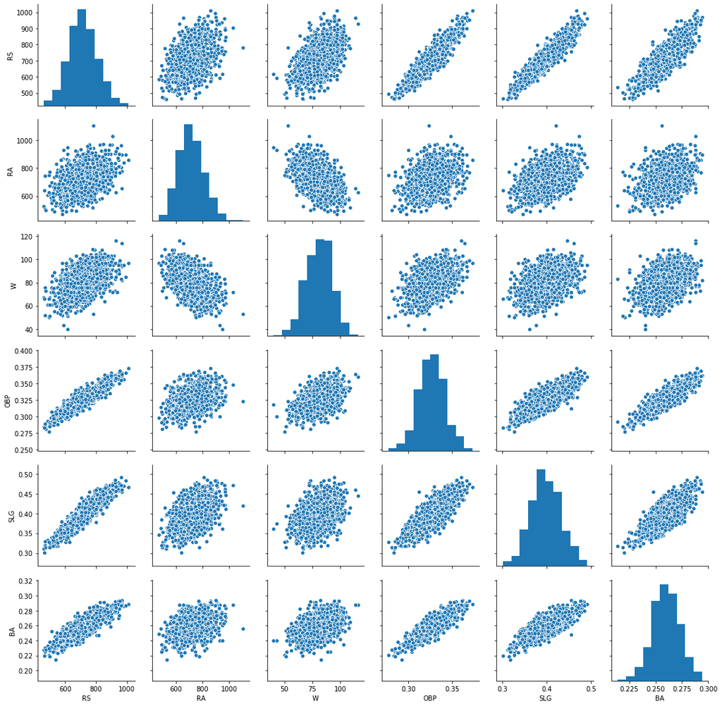

```python
sns.pairplot(pairdf)
plt.show()
```

the above plot shows a scatterplot for the two variables which are being compared.When the variables are the same, then a histogram will be displayed.

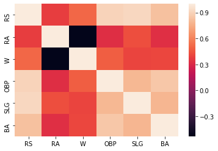

```python
corr = pairdf.corr(method='pearson')
sns.heatmap(corr, xticklabels=corr.columns, yticklabels=corr.columns)
```